# Chapter 9: Support Vector Machines

Paulo Loyola

Loads the libraries.

```r
library(ISLR)
library(e1071)
```

**4)**

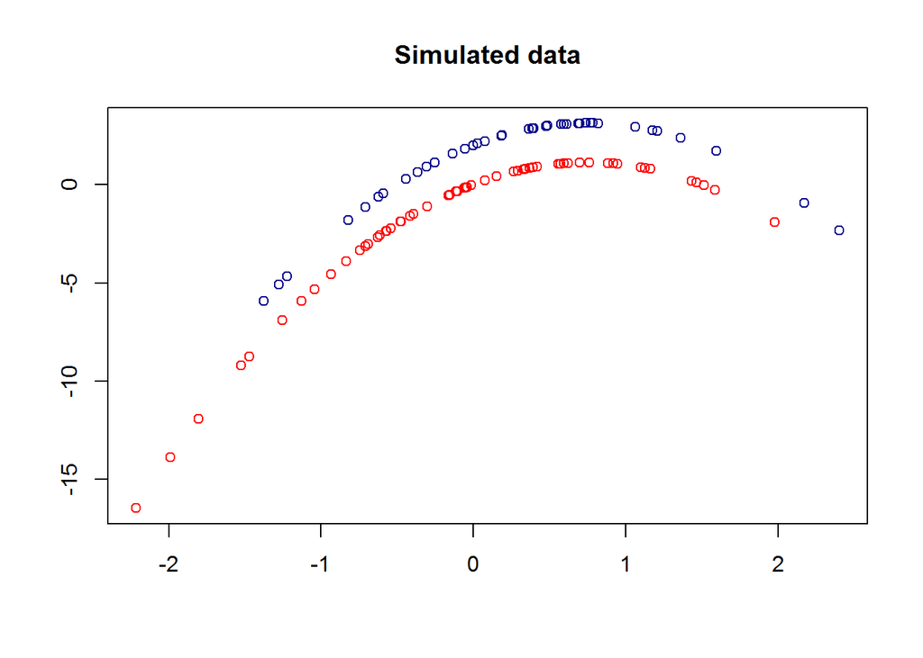

```r
set.seed(1)
x = rnorm(100, 0, 1)
random = rnorm(100, 0, 1)
y = ifelse(random > 0, - 2 * x ^ 2 + 3 * x + 2, - 2 * x ^ 2 + 3 * x)
data2 = as.data.frame(cbind(y, x))
data2$class = ifelse(random <= 0, 1, 0)
data2$class = as.factor(data2$class)
plot(y ~ x, data2, col = ifelse(data2$class == 1, "red", "darkblue"), main = "Simulated data", xlab = "", ylab = "")
```

```r
train = data2[1:75,]
test = data2[76:100,]
```

```r
T.Error = function(model, data, type){
  ypred = predict(model, data)
  if (type == "train") {
    print(table(predict = ypred, type = data$class))
    print("Training Error:")
    return(1 - (table(ypred, data$class)[1,1] + table(ypred, data$class)[2,2])/nrow(data))
  } else if (type == "test") {
    print(table(predict = ypred, type = data$class))
    print("Test Error:")
    return(1 - (table(ypred, data$class)[1,1] + table(ypred, data$class)[2,2])/nrow(data))
  }
}
```

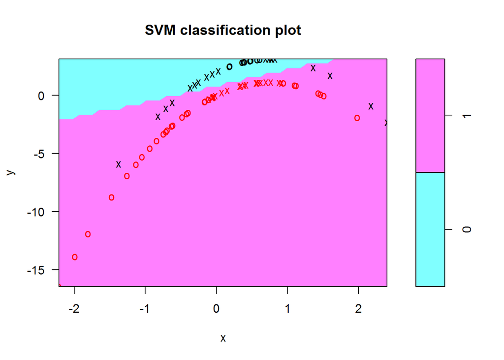

```r
linearfit1 = svm(class ~ ., data = train, kernel = "linear", cost = 5)
plot(linearfit1, train)
```

```r
# Model Fit.
T.Error(linearfit1, train, "train")
```

```
##        type
## predict  0  1
##       0 20  0
##       1  8 47
## [1] "Training Error:"
```

```
## [1] 0.1066667
```

```r
T.Error(linearfit1, test, "test")
```

```
##        type
## predict  0  1
##       0  8  0
##       1  4 13
## [1] "Test Error:"
```

```
## [1] 0.16
```

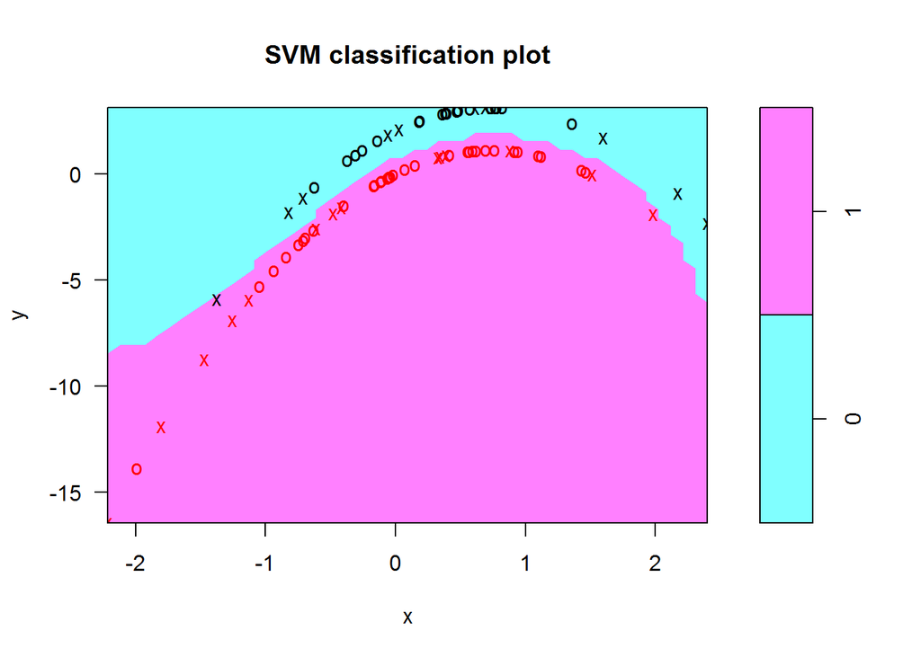

```r
radial = svm(class ~ ., data = train, kernel = "radial", cost = 5, gamma = 1)
plot(radial, train)
```

```r
# Model Fit
T.Error(radial, train, "train")
```

```
##        type
## predict  0  1
##       0 27  0
##       1  1 47
## [1] "Training Error:"
```

```
## [1] 0.01333333
```

```r
T.Error(radial, test, "test")
```

```
##        type
## predict  0  1
##       0 11  0
##       1  1 13
## [1] "Test Error:"
```

```
## [1] 0.04
```

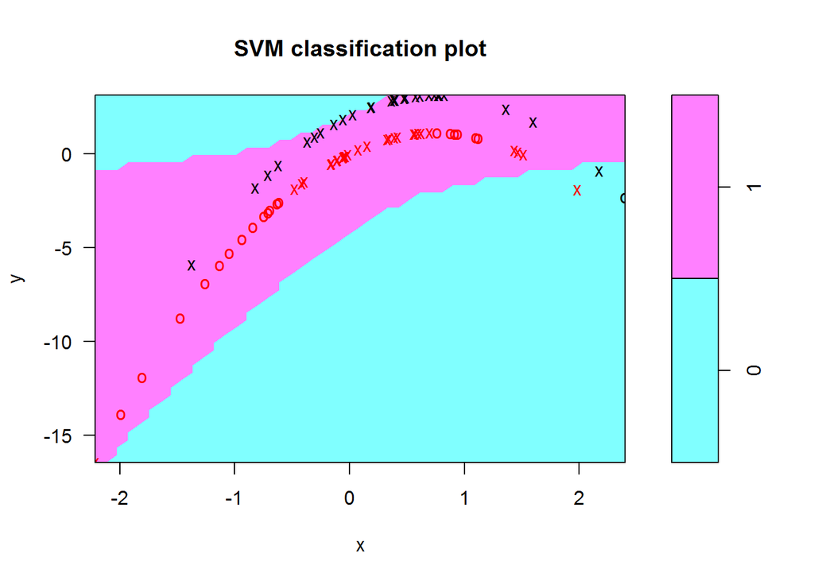

```r
polynomial = svm(class ~ ., data = train, kernel = "polynomial", cost = 5, degree = 2)
plot(polynomial, train)
```

```r
# Model Fit
T.Error(polynomial, train, "train")
```

```
##        type
## predict  0  1
##       0  2  1
##       1 26 46
## [1] "Training Error:"
```

```
## [1] 0.36
```

```r
T.Error(polynomial, test, "test")
```

```
##        type
## predict  0  1
##       0  0  0
##       1 12 13
## [1] "Test Error:"
```

```
## [1] 0.48
```

The results show that the radial model is the one with the best fit to the data. It misclassified only one observation in the training and in the test data. It has a Training Error of $0.013$ and a Test Error of $0.04$.

**5)**

**a) and b)**

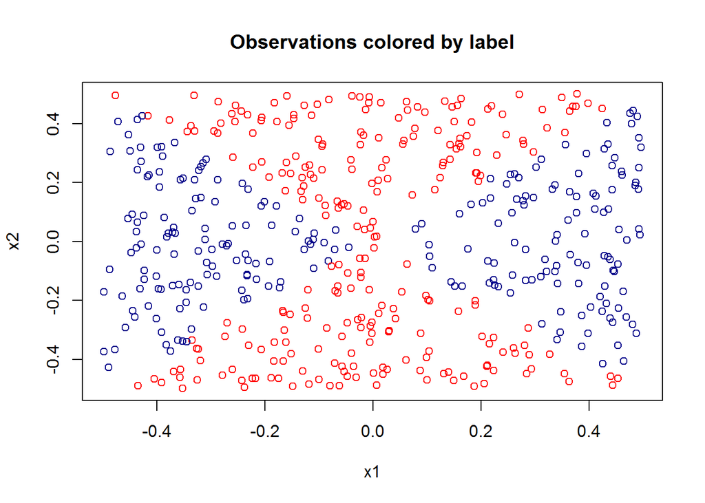

```r
set.seed(1)
x1 = runif(500) - 0.5
x2 = runif(500) - 0.5
y = 1 * (x1 ^ 2 - x2 ^ 2 > 0)
plot(x1, x2, col = ifelse(y == 0, "red", "darkblue"), main = "Observations colored by label")
```

```r
data5 = as.data.frame(cbind(y, x1, x2))
train = sample(500, 400)
test = data5[-train,]
train = data5[train,]
```

**c)**

```r
logistic = glm(y ~ x1 + x2, data5, family = "binomial")
summary(logistic)
```

```
##
## Call:
## glm(formula = y ~ x1 + x2, family = "binomial", data = data5)
##
## Deviance Residuals:
##    Min      1Q  Median      3Q     Max
## -1.179  -1.139  -1.112   1.206   1.257
##
## Coefficients:
##              Estimate Std. Error z value Pr(>|z|)
## (Intercept) -0.087260   0.089579  -0.974    0.330
## x1           0.196199   0.316864   0.619    0.536
## x2          -0.002854   0.305712  -0.009    0.993
##
## (Dispersion parameter for binomial family taken to be 1)
##
##     Null deviance: 692.18  on 499  degrees of freedom
## Residual deviance: 691.79  on 497  degrees of freedom
## AIC: 697.79
##
## Number of Fisher Scoring iterations: 3
```

**d)**

```r
logistic2 = glm(y ~ x1 + x2, train, family = "binomial")
summary(logistic2)
```

```
##
## Call:
## glm(formula = y ~ x1 + x2, family = "binomial", data = train)
##
## Deviance Residuals:
##    Min      1Q  Median      3Q     Max
## -1.206  -1.132  -1.086   1.219   1.284
##
## Coefficients:
##             Estimate Std. Error z value Pr(>|z|)
## (Intercept) -0.09815    0.10022  -0.979    0.327
## x1           0.15421    0.35577   0.433    0.665
## x2          -0.19900    0.34367  -0.579    0.563
##
## (Dispersion parameter for binomial family taken to be 1)
##
##     Null deviance: 553.52  on 399  degrees of freedom
## Residual deviance: 553.02  on 397  degrees of freedom
## AIC: 559.02
##
## Number of Fisher Scoring iterations: 3
```

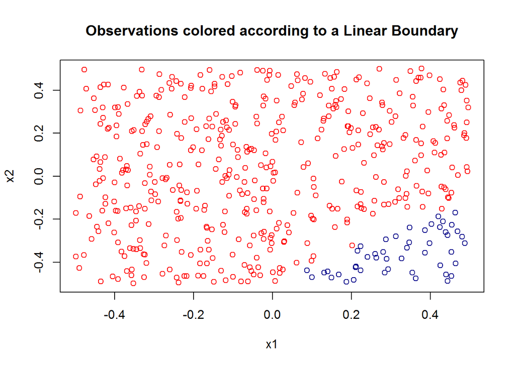

```r
logisticpred = predict(logistic2, data5, type = "response")
linearpred = ifelse(logisticpred > 0.5, 1, 0)
plot(x1, x2, col = ifelse(linearpred == 0, "red", "darkblue"), main = "Observations colored according to a Linear Boundary")
```

**e)**

```r
logistic3 = glm(y ~ poly(x1, 2) + poly(x2, 2) + I(x1 * x2), data5, family = "binomial")
summary(logistic3)
```

```
##
## Call:
## glm(formula = y ~ poly(x1, 2) + poly(x2, 2) + I(x1 * x2), family = "binomial",
##     data = data5)
##
## Deviance Residuals:
##        Min          1Q      Median          3Q         Max
## -8.240e-04  -2.000e-08  -2.000e-08   2.000e-08   1.163e-03
##
## Coefficients:
##              Estimate Std. Error z value Pr(>|z|)
## (Intercept)    -102.2     4302.0  -0.024    0.981
## poly(x1, 2)1   2715.3   141109.5   0.019    0.985
## poly(x1, 2)2  27218.5   842987.2   0.032    0.974
## poly(x2, 2)1   -279.7    97160.4  -0.003    0.998
## poly(x2, 2)2 -28693.0   875451.3  -0.033    0.974
## I(x1 * x2)     -206.4    41802.8  -0.005    0.996
##
## (Dispersion parameter for binomial family taken to be 1)
##
##     Null deviance: 6.9218e+02  on 499  degrees of freedom
## Residual deviance: 3.5810e-06  on 494  degrees of freedom
## AIC: 12
##
## Number of Fisher Scoring iterations: 25
```

**f)**

```r
logistic4 = glm(y ~ poly(x1, 2) + poly(x2, 2) + I(x1 * x2), train, family = "binomial")
summary(logistic4)
```

```
##
## Call:
## glm(formula = y ~ poly(x1, 2) + poly(x2, 2) + I(x1 * x2), family = "binomial",
##     data = train)
##
## Deviance Residuals:
##        Min          1Q      Median          3Q         Max
## -1.032e-03  -2.000e-08  -2.000e-08   2.000e-08   1.107e-03
##
## Coefficients:
##               Estimate Std. Error z value Pr(>|z|)
## (Intercept)     -88.37    5806.51  -0.015    0.988
## poly(x1, 2)1   2551.43  136621.32   0.019    0.985
## poly(x1, 2)2  23091.65  820414.00   0.028    0.978
## poly(x2, 2)1   -774.04  111162.21  -0.007    0.994
## poly(x2, 2)2 -23913.94  858267.56  -0.028    0.978
## I(x1 * x2)     -283.14   52806.24  -0.005    0.996
##
## (Dispersion parameter for binomial family taken to be 1)
##
##     Null deviance: 5.5352e+02  on 399  degrees of freedom
## Residual deviance: 2.7094e-06  on 394  degrees of freedom
## AIC: 12
##
## Number of Fisher Scoring iterations: 25
```

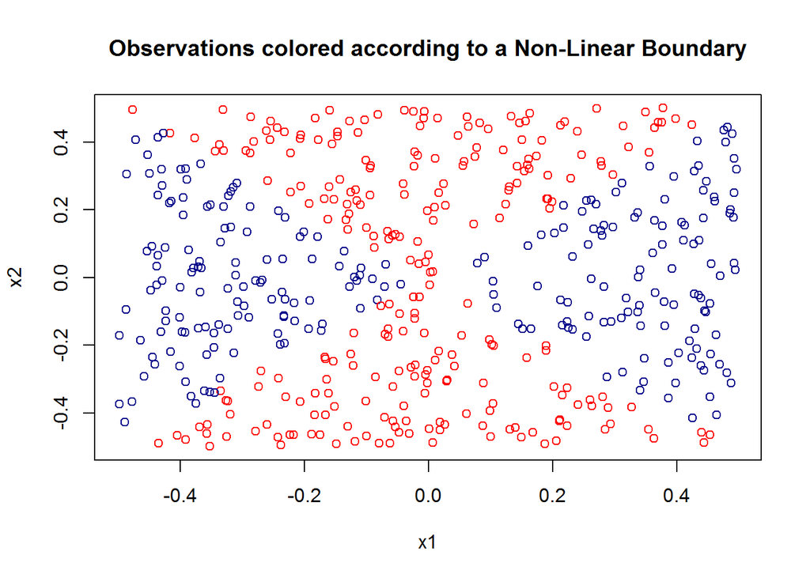

```r
logisticpred = predict(logistic4, data5, type = "response")
linearpred = ifelse(logisticpred > 0.5, 1, 0)
plot(x1, x2, col = ifelse(linearpred == 0, "red", "darkblue"), main = "Observations colored according to a Non-Linear Boundary")
```

**g)**

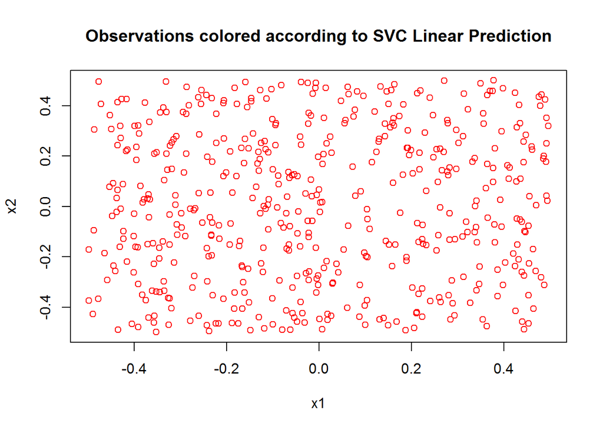

```r
svc = svm(as.factor(y) ~ ., train, kernel = "linear", cost = 0.01, scale = FALSE)
svcpred = predict(svc, data5, type = "response")
plot(x1, x2, col = ifelse(svcpred == 0, "red", "darkblue"), main = "Observations colored according to SVC Linear Prediction")
```

We can see that with a linear kernel the SVC model ends up classifying all the points as a single class, even using a very low cost.

**h)**

[figure not shown]

```r
svc2 = svm(as.factor(y) ~ ., train, gamma = 5)
svc2pred = predict(svc2, data5)
plot(x1, x2, col = ifelse(svc2pred == 0, "red", "darkblue"), main = "Observations colored according to SVC Polynomial Prediction")
```

**i)** We can see that in this case the Support Vector Machine, the Support Vector Model with a non linear decision boundary, outperforms the linear model.

**6)** **a)**

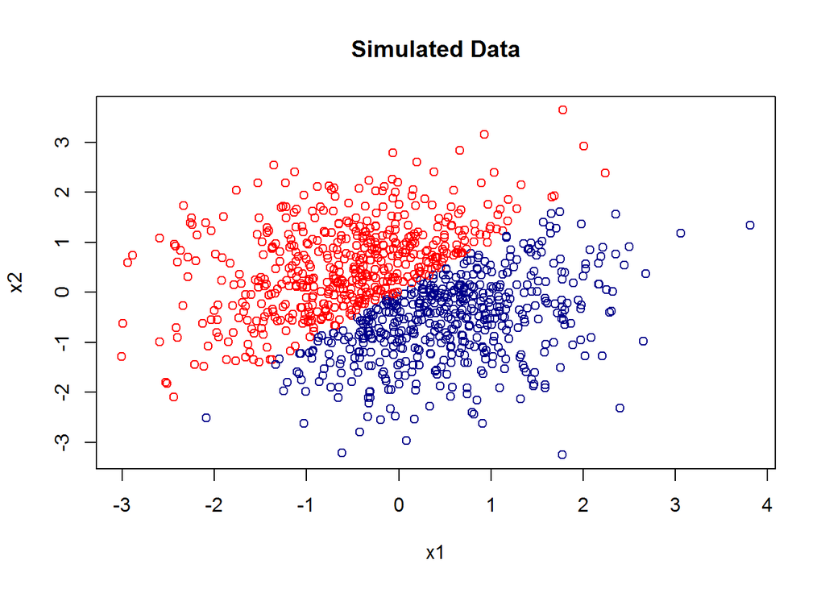

```r
set.seed(1)
x1 <- rnorm(1000, 0, 1)
x2 <- rnorm(1000, 0, 1)
y <- as.factor(ifelse(x1 - x2 > 0, 1, 0))
data6 <- as.data.frame(cbind(y, x1, x2))
plot(x2 ~ x1, data6, col = ifelse(y == 1, "red", "darkblue"), main = "Simulated Data")
```

**b)**

```r
set.seed(1)
tune.out = tune(svm, data6[,c("x1", "x2")], as.factor(y), data6, kernel = "linear", ranges = list(cost = c(0.001, 0.01, 0.1, 1, 5, 10, 100)))
summary(tune.out)
```

```
##
## Parameter tuning of 'svm':
##
## - sampling method: 10-fold cross validation
##
## - best parameters:
##  cost
##    10
##
## - best performance: 0.001
##
## - Detailed performance results:
##    cost error  dispersion
## 1 1e-03 0.027 0.026267851
## 2 1e-02 0.005 0.007071068
## 3 1e-01 0.007 0.009486833
## 4 1e+00 0.004 0.006992059
## 5 5e+00 0.002 0.004216370
## 6 1e+01 0.001 0.003162278
## 7 1e+02 0.001 0.003162278
```

```r
# CV Errors
data.frame(cost = tune.out$performances$cost, misclassified = tune.out$performances$error * nrow(data6))
```

```
##    cost misclassified
## 1 1e-03            27
## 2 1e-02             5
## 3 1e-01             7
## 4 1e+00             4
## 5 5e+00             2
## 6 1e+01             1
## 7 1e+02             1
```

We can see that the model with a cost of $10$ is the one that performs best. It missclassifies 1 observations on the training set.

**c)**

```r
set.seed(1)
train = sample(1000, 800)
test = data6[-train,]
train = data6[train,]
costs = c(10^-3, 10^-2, 10^-1, 10^0, 5, 10^1, 10^2)
train.errors = c()
test.errors = c()
for(i in 1:length(costs)){
  model = svm(as.factor(y) ~ ., train, kernel = "linear", cost = costs[i])
  pred = predict(model, train, type = "response")
  train.errors = c(train.errors, 1 - (table(pred, train$y)[1,1] + table(pred, train$y)[2,2])/nrow(train))
  pred = predict(model, test, type = "response")
  test.errors = c(test.errors, 1 - (table(pred, test$y)[1,1] + table(pred, test$y)[2,2])/nrow(test))
}
data.frame(cost = costs, train.errors, test.errors, train.missclass = train.errors * nrow(train), test.missclass = test.errors * nrow(test))
```

```
##    cost train.errors test.errors train.missclass test.missclass
## 1 1e-03      0.00250       0.015               2              3
## 2 1e-02      0.01500       0.020              12              4
## 3 1e-01      0.00750       0.010               6              2
## 4 1e+00      0.00125       0.000               1              0
## 5 5e+00      0.00250       0.000               2              0
## 6 1e+01      0.00125       0.005               1              1
## 7 1e+02      0.00250       0.015               2              3
```

Comparing the test error of models with different costs we see that the model with the lowest test error is the one with a cost equal to $1$ (it has no missclassification), it also presents one of the lowest training errors (it misclassifies 1 observations in the training data set). Comparing it to the Cross Validation results we see that the CV approach would end up recommending us to use a cost equal to $10$.

**d)** We see that there is no rule of thumb to find the best cost. It can lies on bigger or smaller values depending on the problem we are trying to solve.

**7)** **a)**

```r
Auto2 = Auto
Auto2$mileage = as.factor(ifelse(Auto2$mpg > median(Auto2$mpg), 1, 0))
Auto2 = Auto2[,-9]
```

**b)**

```r
costs = c(10^-2, 10^-1, 10^0, 10^1, 10^2, 10^3)
tuned = tune(svm, Auto2[,-c(9)], Auto2$mileage, kernel = "linear", ranges = list(cost = costs))
data.frame(tuned$performances$cost, tuned$performances$error, missclass = tuned$performances$error * nrow(Auto2))
```

```
##   tuned.performances.cost tuned.performances.error missclass
## 1                   1e-02              0.073910256 28.972821
## 2                   1e-01              0.048525641 19.022051
## 3                   1e+00              0.012820513  5.025641
## 4                   1e+01              0.015384615  6.030769
## 5                   1e+02              0.002564103  1.005128
## 6                   1e+03              0.002564103  1.005128
```

```r
tuned$best.model
```

```
##
## Call:
## best.tune(method = svm, train.x = Auto2[, -c(9)], train.y = Auto2$mileage,
##     ranges = list(cost = costs), kernel = "linear")
##
##
## Parameters:
##    SVM-Type:  C-classification
##  SVM-Kernel:  linear
##        cost:  100
##       gamma:  0.125
##
## Number of Support Vectors:  10
```

The results suggest that the best model to predict mileage is the one with a cost of $100$.

**c)**

```r
tune.radial = tune(svm, Auto2[,-c(9)], Auto2$mileage, kernel = "radial", ranges = list(cost = costs, gamma = c(0.5, 1, 2, 3, 4)))
data.frame(cost = tune.radial$performances$cost, gamma = tune.radial$performances$gamma, error = tune.radial$performances$error, missclass = tune.radial$performances$error * nrow(Auto2))
```

```
##     cost gamma      error missclass
## 1  1e-02   0.5 0.56634615 222.00769
## 2  1e-01   0.5 0.08403846  32.94308
## 3  1e+00   0.5 0.04089744  16.03179
## 4  1e+01   0.5 0.03833333  15.02667
## 5  1e+02   0.5 0.04596154  18.01692
## 6  1e+03   0.5 0.04596154  18.01692
## 7  1e-02   1.0 0.56634615 222.00769
## 8  1e-01   1.0 0.08910256  34.92821
## 9  1e+00   1.0 0.04596154  18.01692
## 10 1e+01   1.0 0.05365385  21.03231
## 11 1e+02   1.0 0.05365385  21.03231
## 12 1e+03   1.0 0.05365385  21.03231
## 13 1e-02   2.0 0.56634615 222.00769
## 14 1e-01   2.0 0.17358974  68.04718
```

[output cut: 16 more lines]

```r
tune.radial$best.model
```

```
##
## Call:
## best.tune(method = svm, train.x = Auto2[, -c(9)], train.y = Auto2$mileage,
##     ranges = list(cost = costs, gamma = c(0.5, 1, 2, 3, 4)),
##     kernel = "radial")
##
##
## Parameters:
##    SVM-Type:  C-classification
##  SVM-Kernel:  radial
##        cost:  10
##       gamma:  0.5
##
## Number of Support Vectors:  89
```

```r
tune.poly = tune(svm, Auto2[,-c(9)], Auto2$mileage, kernel = "polynomial", ranges = list(cost = costs, degree = c(2, 3, 4, 5)))
data.frame(cost = tune.poly$performances$cost, degree = tune.poly$performances$degree, error = tune.poly$performances$error, missclass = tune.poly$performances$error * nrow(Auto2))
```

```
##     cost degree      error missclass
## 1  1e-02      2 0.48532051 190.24564
## 2  1e-01      2 0.28057692 109.98615
## 3  1e+00      2 0.22705128  89.00410
## 4  1e+01      2 0.18858974  73.92718
## 5  1e+02      2 0.18070513  70.83641
## 6  1e+03      2 0.18089744  70.91179
## 7  1e-02      3 0.25782051 101.06564
## 8  1e-01      3 0.15076923  59.10154
## 9  1e+00      3 0.07929487  31.08359
## 10 1e+01      3 0.03564103  13.97128
## 11 1e+02      3 0.03576923  14.02154
## 12 1e+03      3 0.03570513  13.99641
## 13 1e-02      4 0.38801282 152.10103
## 14 1e-01      4 0.27551282 108.00103
## 15 1e+00      4 0.23775641  93.20051
## 16 1e+01      4 0.17089744  66.99179
## 17 1e+02      4 0.11480769  45.00462
## 18 1e+03      4 0.12250000  48.02000
## 19 1e-02      5 0.28070513 110.03641
## 20 1e-01      5 0.25782051 101.06564
## 21 1e+00      5 0.13256410  51.96513
## 22 1e+01      5 0.09685897  37.96872
## 23 1e+02      5 0.05871795  23.01744
## 24 1e+03      5 0.05615385  22.01231
```

```r
tune.poly$best.model
```

```
##
## Call:
## best.tune(method = svm, train.x = Auto2[, -c(9)], train.y = Auto2$mileage,
##     ranges = list(cost = costs, degree = c(2, 3, 4, 5)), kernel = "polynomial")
##
##
## Parameters:
##    SVM-Type:  C-classification
##  SVM-Kernel:  polynomial
##        cost:  10
##      degree:  3
##       gamma:  0.125
##      coef.0:  0
##
## Number of Support Vectors:  75
```

**d)** The graphs helps to see how the linear model makes better predictions than the others.

```r
bestlinear = svm(mileage ~ ., data = Auto2, kernel = "linear", cost = 100)
bestradial = svm(mileage ~ ., data = Auto2, kernel = "radial", gamma = 0.5, cost = 10)
bestpoly = svm(mileage ~ ., data = Auto2, kernel = "polynomial", degree = 3, cost = 10)
```

```r
plotpairs = function(model) {
  for(name in names(Auto2)[!(names(Auto2) %in% c("mpg", "mileage"))]) {
    plot(model, Auto2, as.formula(paste("mpg~", name, sep = "")))
  }
}
```

Best Linear Model (SVC):

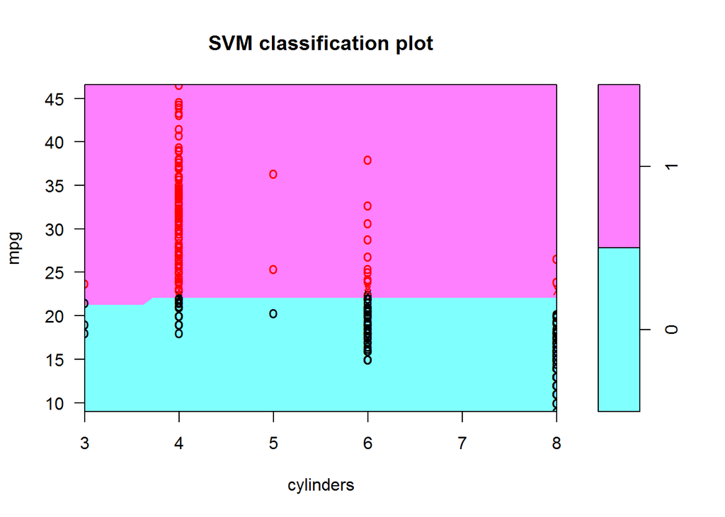

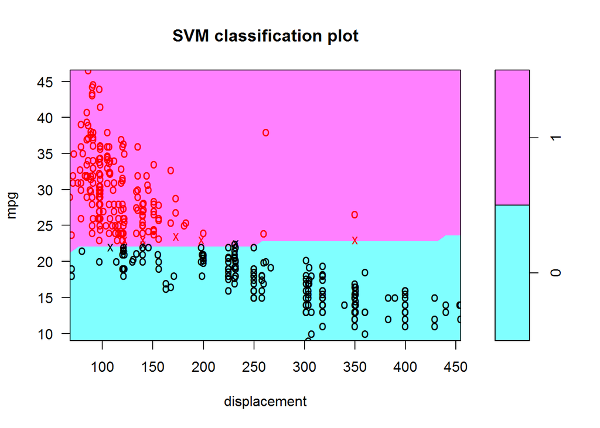

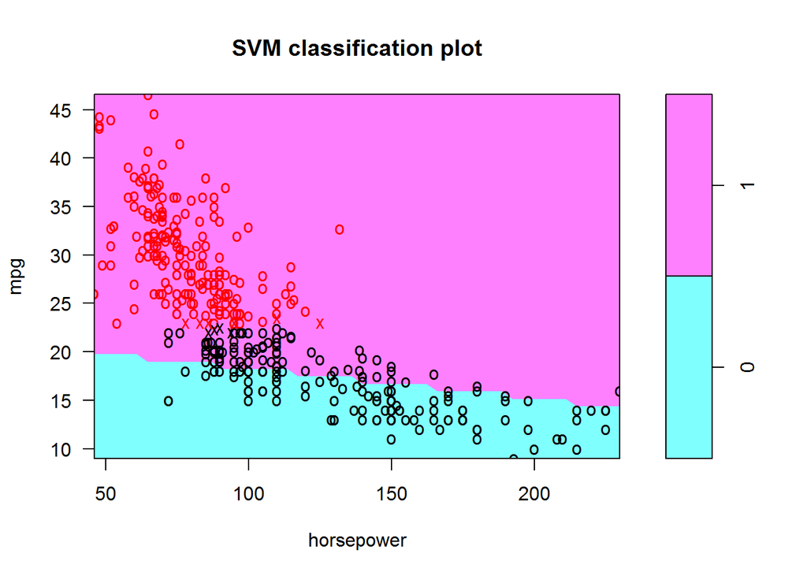

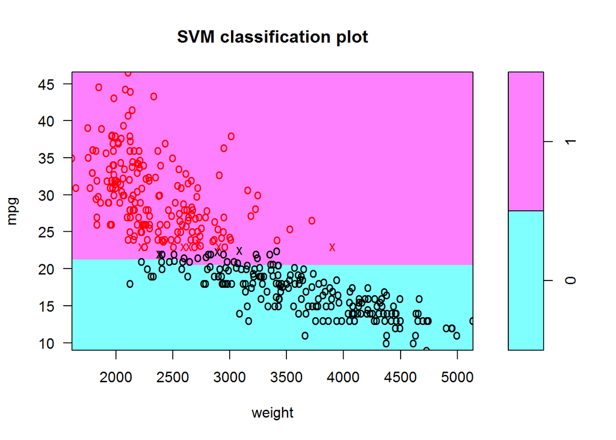

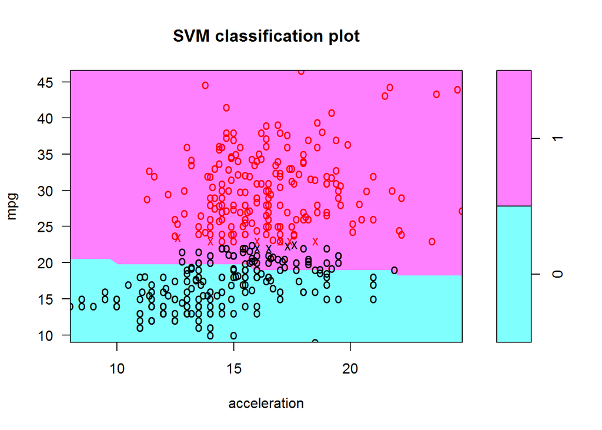

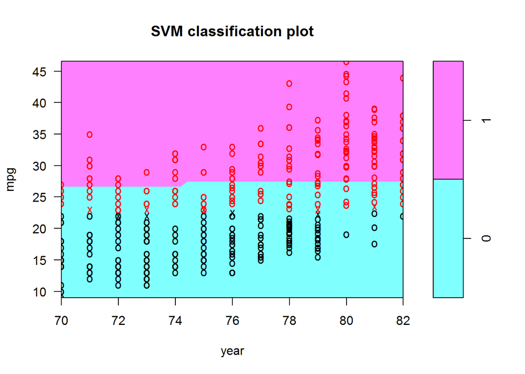

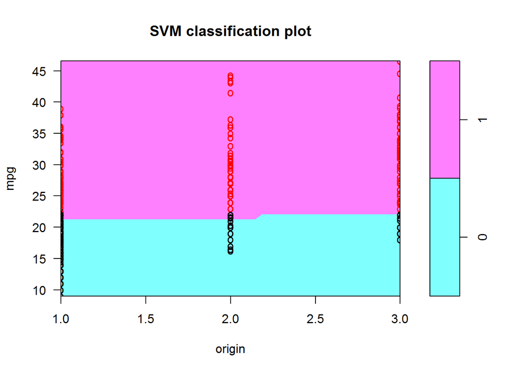

```r
plotpairs(bestlinear)
```

Best Radial Model:

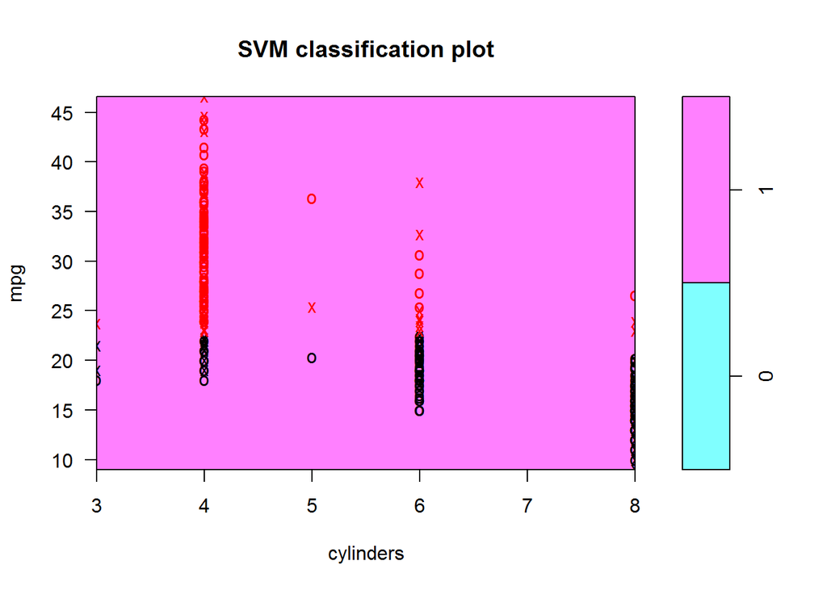

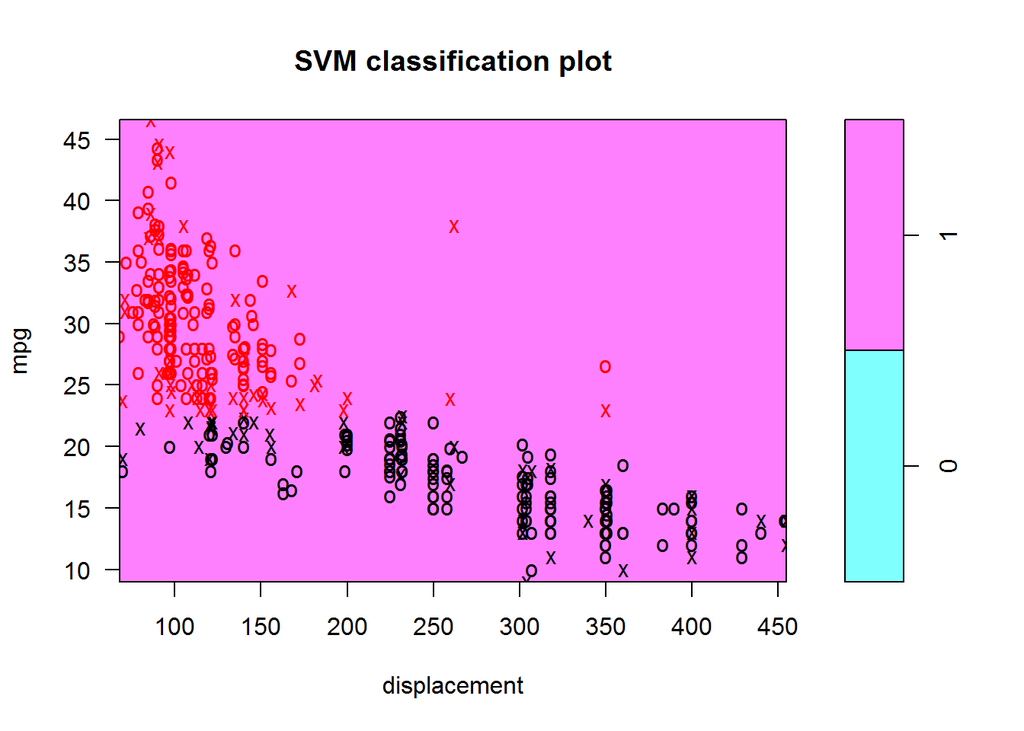

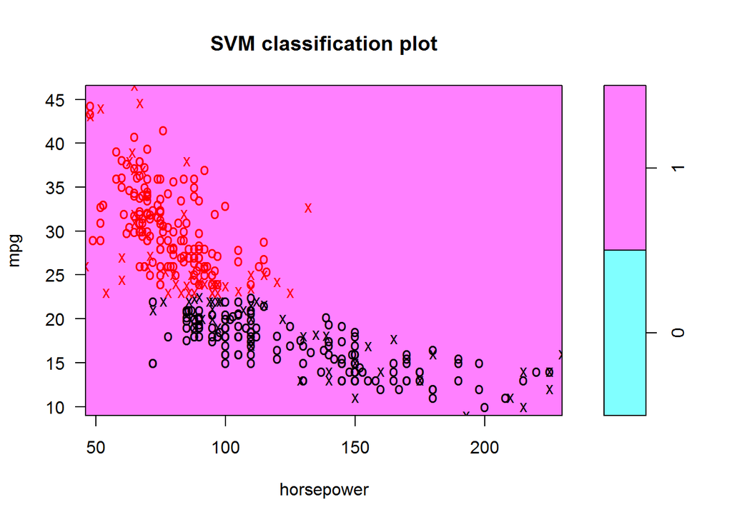

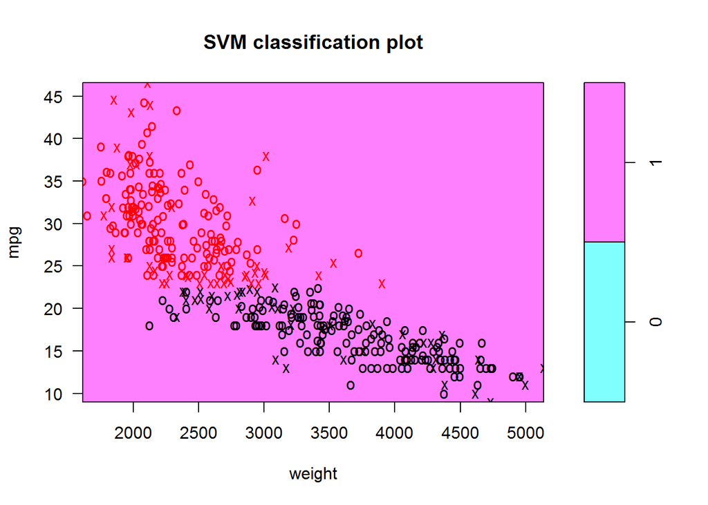

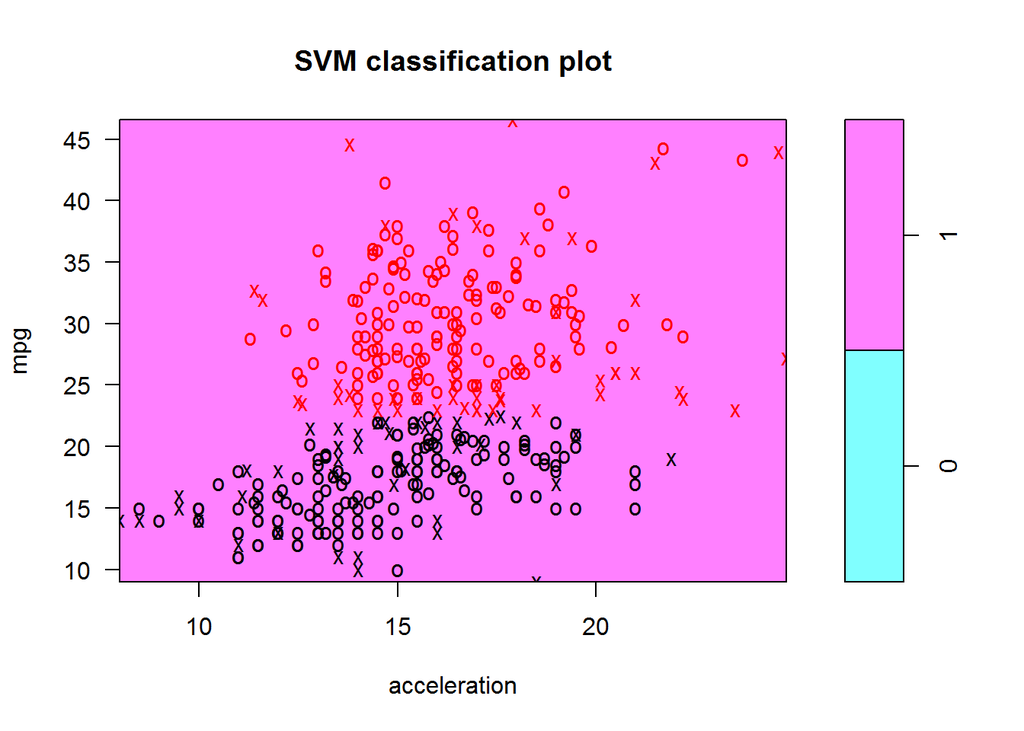

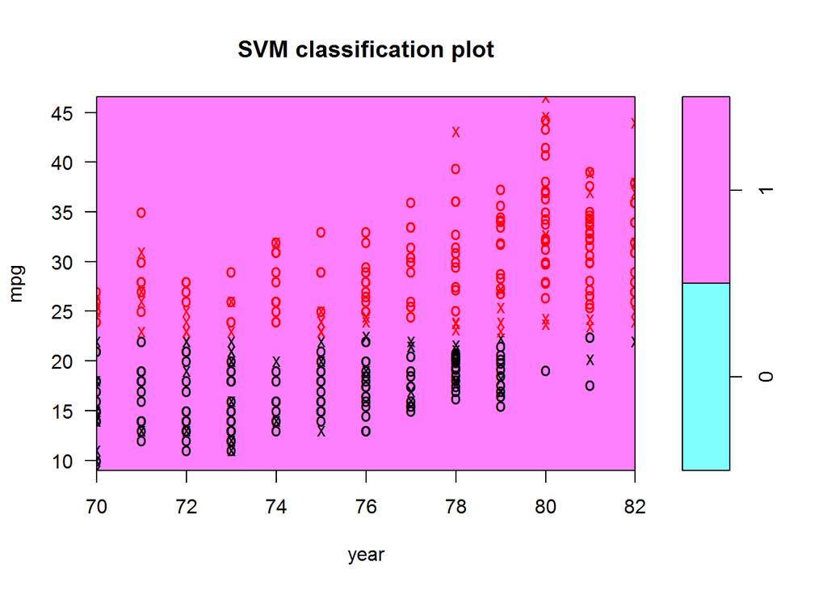

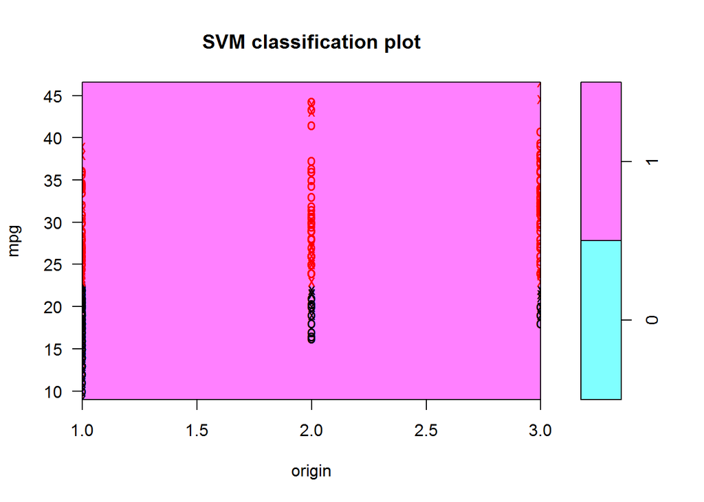

```r
plotpairs(bestradial)
```

Best Polynomial Model:

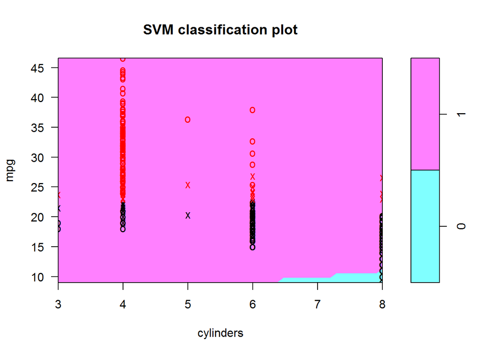

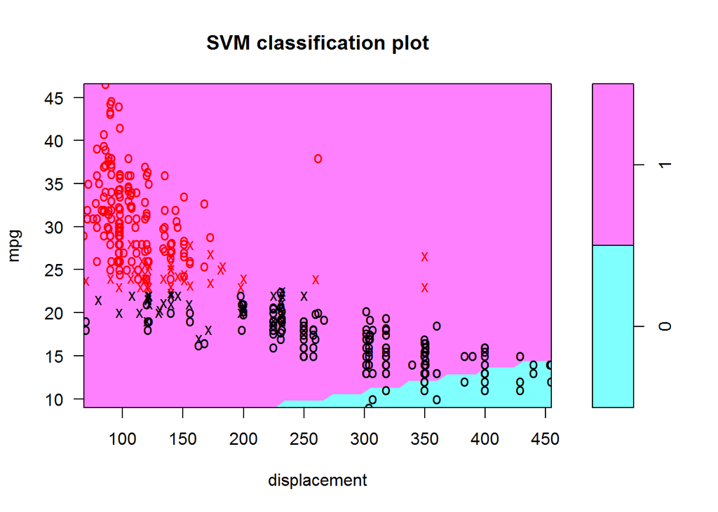

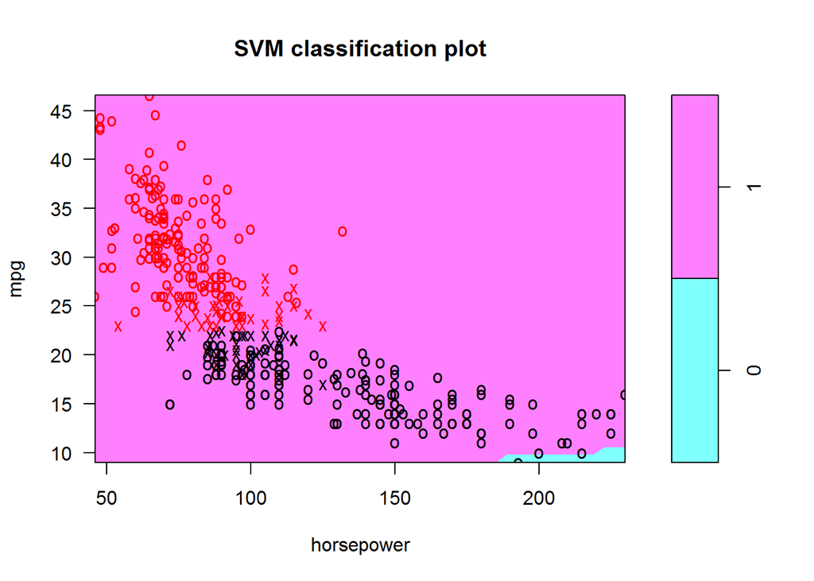

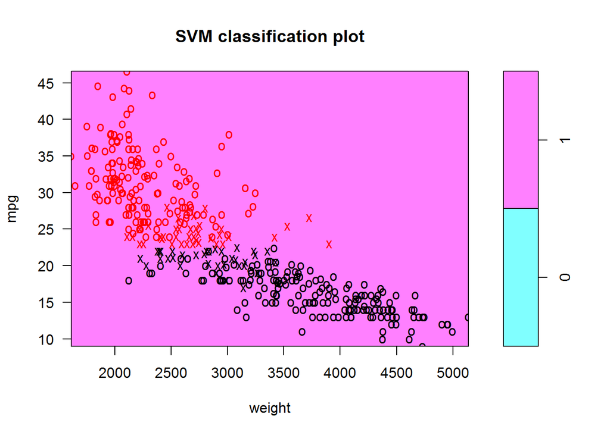

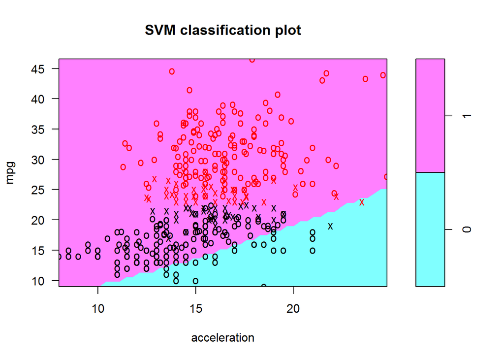

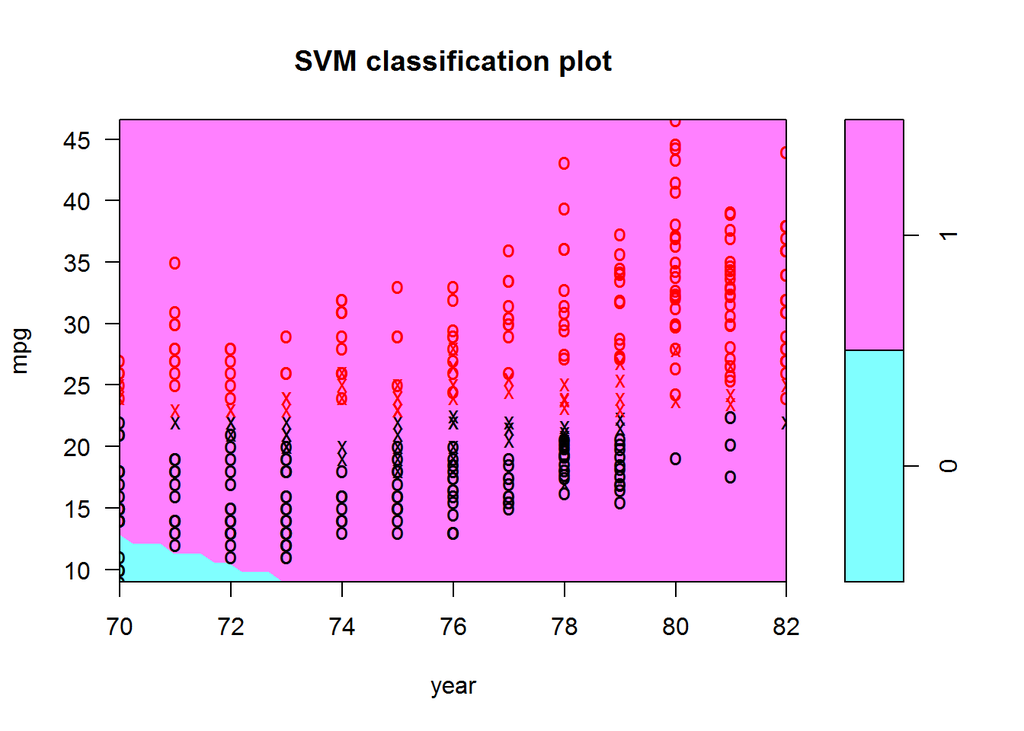

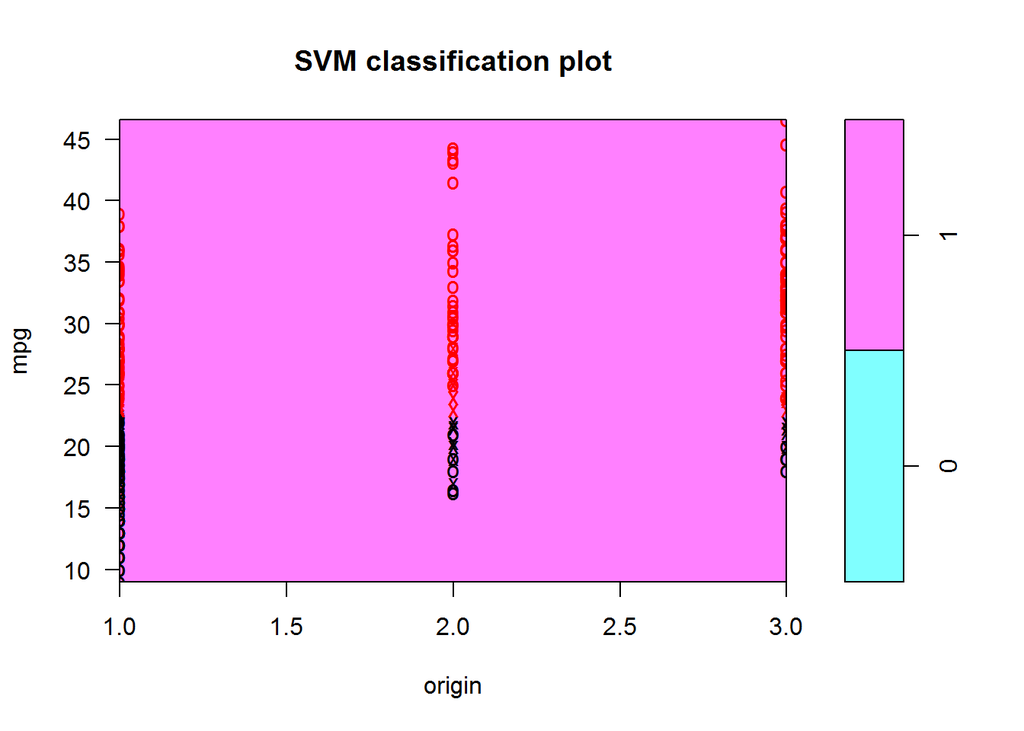

```r
plotpairs(bestpoly)
```

**8)** **a)**

```r
set.seed(1)
train = sample(nrow(OJ), 800)
test = OJ[-train,]
train = OJ[train,]
```

**b)**

```r
svc = svm(Purchase ~ ., train, kernel = "linear", cost = 0.01)
summary(svc)
```

```
##
## Call:
## svm(formula = Purchase ~ ., data = train, kernel = "linear",
##     cost = 0.01)
##
##
## Parameters:
##    SVM-Type:  C-classification
##  SVM-Kernel:  linear
##        cost:  0.01
##       gamma:  0.05555556
##
## Number of Support Vectors:  432
##
##  ( 215 217 )
##
##
## Number of Classes:  2
##
## Levels:
##  CH MM
```

The previous model used 432 observations as support vector and it classified 215 of them as “CH” and the other 217 observations as “MM”.

**c)**

```r
T.Error = function(model, data, type){
  ypred = predict(model, data, type = "response")
  if (type == "train") {
    print(table(predict = ypred, type = data$Purchase))
    print("Training Error:")
    return(1 - (table(ypred, data$Purchase)[1,1] + table(ypred, data$Purchase)[2,2])/nrow(data))
  } else if (type == "test") {
    print(table(predict = ypred, type = data$Purchase))
    print("Test Error:")
    return(1 - (table(ypred, data$Purchase)[1,1] + table(ypred, data$Purchase)[2,2])/nrow(data))
  }
}
T.Error(svc, train, "train")
```

```
##        type
## predict  CH  MM
##      CH 439  78
##      MM  55 228
## [1] "Training Error:"
```

```
## [1] 0.16625
```

```r
T.Error(svc, test, "test")
```

```
##        type
## predict  CH  MM
##      CH 141  31
##      MM  18  80
## [1] "Test Error:"
```

```
## [1] 0.1814815
```

This model has a Training Error Rate of $0.16625$ and a Test Error Rate of $0.18148$.

**d)**

```r
costs = 10^seq(-2, 1, 0.5)
svc.tune = tune(svm, Purchase ~ ., data = OJ, kernel = "linear", ranges = list(cost = costs))
summary(svc.tune)
```

```
##
## Parameter tuning of 'svm':
##
## - sampling method: 10-fold cross validation
##
## - best parameters:
##  cost
##     1
##
## - best performance: 0.1663551
##
## - Detailed performance results:
##          cost     error dispersion
## 1  0.01000000 0.1719626 0.03361023
## 2  0.03162278 0.1719626 0.03557409
## 3  0.10000000 0.1700935 0.03784758
## 4  0.31622777 0.1700935 0.03627645
## 5  1.00000000 0.1663551 0.03759029
## 6  3.16227766 0.1672897 0.03618270
## 7 10.00000000 0.1719626 0.03920781
```

```r
summary(svc.tune$best.model)
```

```
##
## Call:
## best.tune(method = svm, train.x = Purchase ~ ., data = OJ, ranges = list(cost = costs),
##     kernel = "linear")
##
##
## Parameters:
##    SVM-Type:  C-classification
##  SVM-Kernel:  linear
##        cost:  1
##       gamma:  0.05555556
##
## Number of Support Vectors:  442
##
##  ( 221 221 )
##
##
## Number of Classes:  2
##
## Levels:
##  CH MM
```

**e)**

```r
svc.best = svm(Purchase ~ ., train, kernel = "linear", cost = 1)
T.Error(svc.best, train, "train")
```

```
##        type
## predict  CH  MM
##      CH 440  73
##      MM  54 233
## [1] "Training Error:"
```

```
## [1] 0.15875
```

```r
T.Error(svc.best, test, "test")
```

```
##        type
## predict  CH  MM
##      CH 140  33
##      MM  19  78
## [1] "Test Error:"
```

```
## [1] 0.1925926
```

**f)** Repeat parts (b) through (e) using a support vector machine with a radial kernel. Use the default value for gamma.

```r
svm.radial = svm(Purchase ~ ., train, kernel = "radial", cost = 0.01)
summary(svm.radial)
```

```
##
## Call:
## svm(formula = Purchase ~ ., data = train, kernel = "radial",
##     cost = 0.01)
##
##
## Parameters:
##    SVM-Type:  C-classification
##  SVM-Kernel:  radial
##        cost:  0.01
##       gamma:  0.05555556
##
## Number of Support Vectors:  617
##
##  ( 306 311 )
##
##
## Number of Classes:  2
##
## Levels:
##  CH MM
```

```r
T.Error(svm.radial, train, "train")
```

```
##        type
## predict  CH  MM
##      CH 494 306
##      MM   0   0
## [1] "Training Error:"
```

```
## [1] 0.3825
```

```r
T.Error(svm.radial, test, "test")
```

```
##        type
## predict  CH  MM
##      CH 159 111
##      MM   0   0
## [1] "Test Error:"
```

```
## [1] 0.4111111
```

```r
svm.radial.tune = tune(svm, Purchase ~ ., data = OJ, kernel = "radial", ranges = list(cost = costs))
summary(svm.radial.tune)
```

```
##
## Parameter tuning of 'svm':
##
## - sampling method: 10-fold cross validation
##
## - best parameters:
##       cost
##  0.3162278
##
## - best performance: 0.1700935
##
## - Detailed performance results:
##          cost     error dispersion
## 1  0.01000000 0.3897196 0.04180727
## 2  0.03162278 0.2392523 0.04929605
## 3  0.10000000 0.1794393 0.02915728
## 4  0.31622777 0.1700935 0.02322910
## 5  1.00000000 0.1738318 0.02861977
## 6  3.16227766 0.1747664 0.03053913
## 7 10.00000000 0.1775701 0.03267317
```

```r
summary(svm.radial.tune$best.model)
```

```
##
## Call:
## best.tune(method = svm, train.x = Purchase ~ ., data = OJ, ranges = list(cost = costs),
##     kernel = "radial")
##
##
## Parameters:
##    SVM-Type:  C-classification
##  SVM-Kernel:  radial
##        cost:  0.3162278
##       gamma:  0.05555556
##
## Number of Support Vectors:  557
##
##  ( 281 276 )
##
##
## Number of Classes:  2
##
## Levels:
##  CH MM
```

```r
svm.radial.best = svm(Purchase ~ ., train, kernel = "radial", cost = 0.5)
T.Error(svm.radial.best, train, "train")
```

```
##        type
## predict  CH  MM
##      CH 453  77
##      MM  41 229
## [1] "Training Error:"
```

```
## [1] 0.1475
```

```r
T.Error(svm.radial.best, test, "test")
```

```
##        type
## predict  CH  MM
##      CH 143  29
##      MM  16  82
## [1] "Test Error:"
```

```
## [1] 0.1666667
```

**g)**

```r
svm.poly = svm(Purchase ~ ., train, kernel = "polynomial", degree = 2, cost = 0.01)
summary(svm.poly)
```

```
##
## Call:
## svm(formula = Purchase ~ ., data = train, kernel = "polynomial",
##     degree = 2, cost = 0.01)
##
##
## Parameters:
##    SVM-Type:  C-classification
##  SVM-Kernel:  polynomial
##        cost:  0.01
##      degree:  2
##       gamma:  0.05555556
##      coef.0:  0
##
## Number of Support Vectors:  620
##
##  ( 306 314 )
##
##
## Number of Classes:  2
##
## Levels:
##  CH MM
```

```r
T.Error(svm.poly, train, "train")
```

```
##        type
## predict  CH  MM
##      CH 494 306
##      MM   0   0
## [1] "Training Error:"
```

```
## [1] 0.3825
```

```r
T.Error(svm.poly, test, "test")
```

```
##        type
## predict  CH  MM
##      CH 159 111
##      MM   0   0
## [1] "Test Error:"
```

```
## [1] 0.4111111
```

```r
svm.poly.tune = tune(svm, Purchase ~ ., data = OJ, kernel = "polynomial", degree = 2, ranges = list(cost = costs))
summary(svm.poly.tune)
```

```
##
## Parameter tuning of 'svm':
##
## - sampling method: 10-fold cross validation
##
## - best parameters:
##  cost
##    10
##
## - best performance: 0.1747664
##
## - Detailed performance results:
##          cost     error dispersion
## 1  0.01000000 0.3728972 0.03749982
## 2  0.03162278 0.3411215 0.04115216
## 3  0.10000000 0.3037383 0.04344650
## 4  0.31622777 0.2046729 0.03671522
## 5  1.00000000 0.1915888 0.03503807
## 6  3.16227766 0.1850467 0.03519008
## 7 10.00000000 0.1747664 0.03498263
```

```r
summary(svm.poly.tune$best.model)
```

```
##
## Call:
## best.tune(method = svm, train.x = Purchase ~ ., data = OJ, ranges = list(cost = costs),
##     kernel = "polynomial", degree = 2)
##
##
## Parameters:
##    SVM-Type:  C-classification
##  SVM-Kernel:  polynomial
##        cost:  10
##      degree:  2
##       gamma:  0.05555556
##      coef.0:  0
##
## Number of Support Vectors:  450
##
##  ( 230 220 )
##
##
## Number of Classes:  2
##
## Levels:
##  CH MM
```

```r
svm.poly.best = svm(Purchase ~ ., train, kernel = "polynomial", degree = 2, cost = 10)
T.Error(svm.poly.best, train, "train")
```

```
##        type
## predict  CH  MM
##      CH 450  72
##      MM  44 234
## [1] "Training Error:"
```

```
## [1] 0.145
```

```r
T.Error(svm.poly.best, test, "test")
```

```
##        type
## predict  CH  MM
##      CH 140  31
##      MM  19  80
## [1] "Test Error:"
```

```
## [1] 0.1851852
```

**h)** Overall, the Support Vector Machine with a radial kernel seems to present the best results on the test data, meanwhile the Support Vector Machine with a polynomial kernel presents the lowest training error rate.